# Meta analysis

# Load data

We load data from a CSV exported from Stata. The `Mo` variables refer to what happens after 6 months. The `W`, `X`, `Y`, `Z`, `AA` variables refer to what happens after 12 months. That’s a bug in how Stata exports names of variables which start with a number - the columns were named `6mo...` and `12mo...`.

```r
library(tidyverse)
library(meta)
library(ggrepel)

setwd("~/Documents/phaco")
df <- read.csv("phaco.csv", na.strings='-')
df <- df %>% rename(SixMoEyes = MoEyes,
              SixMoIOPMean = MoIOPMean,
              SixMoIOPStdDev = MoIOPStdDev,
              SixMoAbsIOPChangeMean = MoAbsIOPChangeMean,
              SixMoAbsIOPChangeStdDev = MoAbsIOPChangeStdDev,
              OneYEyes = W,
              OneYIOPMean = X,
              OneYIOPStdDev = Y,
              OneYAbsIOPChangeMean = Z,
              OneYAbsIOPChangeStdDev = AA,
              LastPeriodAbsIOPChangeStdDev = LastPeriodAbsIOPChangeStd,
              LastPeriodEyes = LastPeriodofEyes
              )

df <- df %>% mutate(subtype = as.factor(ifelse(is.na(OAG), 'OAG',
                          ifelse(OAG > 50, 'OAG',
                                 ifelse(ACG > 50, 'ACG',
                                        ifelse(PXG > 50, 'PXG', NA))))))

df <- df %>% mutate(study.name = paste0(Author, ' (', Year, ')'))
```

# Analysis without imputation

## 6 month follow-up

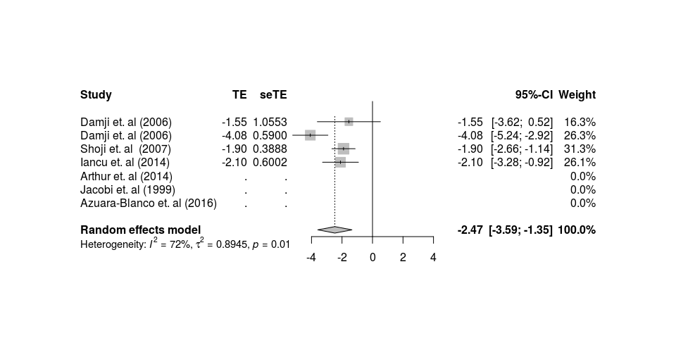

```r
m <- metagen(SixMoAbsIOPChangeMean,
             SixMoAbsIOPChangeStdDev / sqrt(SixMoEyes),
             study.name,
             data=df,
             subset=!is.na(df$SixMoEyes))
forest(m, comb.fixed=FALSE)
```

## 12-month follow up

```r
m <- metagen(OneYAbsIOPChangeMean,
             OneYAbsIOPChangeStdDev / sqrt(OneYEyes),
             study.name,
             data=df,
             subset=!is.na(df$OneYAbsIOPChangeMean))
forest(m, comb.fixed = FALSE)
```

[output not shown]

## Last period

```r
m <- metagen(LastPeriodAbsIOPChangeMean,
             LastPeriodAbsIOPChangeStdDev / sqrt(LastPeriodEyes),
             study.name,
             data=df,
             subset=!is.na(df$LastPeriodAbsIOPChangeMean))
forest(m, comb.fixed = FALSE)
```

[output not shown]

## Subgroup analysis

```r
m <- metagen(LastPeriodAbsIOPChangeMean,
             LastPeriodAbsIOPChangeStdDev / sqrt(LastPeriodEyes),
             study.name,
             data=df,
             subset=!is.na(df$LastPeriodAbsIOPChangeMean),
             byvar=subtype)
forest(m, comb.fixed = FALSE)
```

[output not shown]

# Analyses with imputation

I’m going to start by imputing on the basis of a low loss in follow up, high correlation between pre and post measures, and no change in relative IOP for those patients that were lost in follow up.

```r
# Consider two range of loss of follow up.
losses <- list(lo=c(.94, .91, .87),
               hi=c(.82, .72, .51))
# Assume a range of correlations between PreOp and PostOp periods.
corrs <- list(lo=c(.25, .25, .25),
              hi=c(.45, .45, .45))
# And a range of outcomes for the missing eyes.
deltas <- list(lo=c(0, 0, 0),  # Same outcome in the unseen arm.
               hi=c(5, 5, 5))  # Worse outcome in the unseen arm.
infer.mean.sem <- function(N.b, m.b, s.b, N.a, m.a, s.a, m.d, s.d, rho, m.delta) {
  # Infer the mean and SEM of the deviation in the metric measured before and after the intervention.
  # N.b, m.b, s.b: N, mean, S.D. of metric before the intervention
  # N.a, m.a, s.a: N, mean, S.D. of metric after the intervention
  # m.d, s.d: mean, S.D. of metric after intervention minus the metric before the intervention for
  #   the group of survivors (N.a). Can be NA.
  # rho: Assumed correlation between before and after scores. Will be used to infer s.d. if s.d is NA
  # m.delta: the assumed mean delta between the m.b for the non-survivors minus the survivors.
  # Use equations in Section 6.1 of Schwarzer, Carpenter & Rucker (2014), Meta-Analysis with R
  m.d <- ifelse(is.na(m.d), m.a - m.b, m.d)
  s.d <- ifelse(is.na(s.d), sqrt(s.a ** 2 + s.b ** 2 - 2 * rho * s.a * s.b), s.d)

  # Now generalize the mean difference from the observed subset to the full dataset.
  # pi := unobserved portion
  pi = (N.b - N.a) / N.b
  m.d.full <- m.d + pi * m.delta
  # Let's assume that delta ~ N(m.delta, s.d)
  sem.d.full <- sqrt(1 + pi ** 2) * s.d / sqrt(N.a)
  return(data.frame(m=m.d.full, sem=sem.d.full))
}
library(testthat)
expect_equal(infer.mean.sem(25, 0, 1, 25, 0, 1, NA, NA, 0, 0)$sem, sqrt(2)/sqrt(25))
expect_equal(infer.mean.sem(25, 0, 1, 25, 0, 1, NA, NA, 0.5, 0)$sem, 1/sqrt(25))
expect_equal(infer.mean.sem(25, 0, 1, 25, 0, 1, NA, NA, 0, 0)$m, 0)
expect_equal(infer.mean.sem(25, 0, 1, 16, 0, 1, NA, NA, 0, 0)$sem, sqrt(1 + (9 / 25) ** 2) * sqrt(2)/sqrt(16))
expect_equal(infer.mean.sem(25, -1, 1, 16, 2, 1, NA, NA, 0, 0)$m, 3)
expect_equal(infer.mean.sem(25, -1, 1, 16, 2, 1, NA, NA, 0, 0)$m, 3)
expect_equal(infer.mean.sem(20, 5, 1, 20, -5, 1, NA, NA, 0, 10)$m, -10)
expect_equal(infer.mean.sem(20, 5, 1, 10, -5, 1, NA, NA, 0, 20)$m, 0)
impute.df <- function(df, loss, corr, delta) {
  # Impute missing data using the bone-headed method of just assuming the mean effect of
  # - loss of follow-up
  # - correlation between Pre and Post IOP metrics
  # - delta between IOP of eyes that were lost in follow up and eyes that were ok.
  df <- df %>% mutate(imp.SixMoEyes = ifelse(is.na(SixMoEyes), round(loss[1] * PreOpEyes), SixMoEyes),
                      imp.OneYEyes = ifelse(is.na(OneYEyes), round(loss[2] * PreOpEyes), OneYEyes),
                      imp.LastPeriodEyes = ifelse(is.na(LastPeriodEyes), round(loss[3] * PreOpEyes), LastPeriodEyes))

  df_ <- with(df, infer.mean.sem(PreOpEyes, PreOpIOPMean, PreOpIOPStdDev,
                                 imp.SixMoEyes, SixMoIOPMean, SixMoIOPStdDev,
                                 SixMoAbsIOPChangeMean, SixMoAbsIOPChangeStdDev, corr[1], delta[1]))

  df$imp.SixMoIOPChangeMean <- df_$m
  df$imp.SixMoIOPChangeSEM <- df_$sem

  df_ <- with(df, infer.mean.sem(PreOpEyes, PreOpIOPMean, PreOpIOPStdDev,
                                 imp.OneYEyes, OneYIOPMean, OneYIOPStdDev,
                                 OneYAbsIOPChangeMean, OneYAbsIOPChangeStdDev, corr[2], delta[2]))
  df$imp.OneYIOPChangeMean <- df_$m
  df$imp.OneYIOPChangeSEM <- df_$sem

  df_ <- with(df, infer.mean.sem(PreOpEyes, PreOpIOPMean, PreOpIOPStdDev,
                                 imp.LastPeriodEyes, LastPeriodIOPMean, LastPeriodIOPStdDev,
                                 LastPeriodAbsIOPChangeMean, LastPeriodAbsIOPChangeStdDev, corr[3], delta[3]))
  df$imp.LastPeriodIOPChangeMean <- df_$m
  df$imp.LastPeriodIOPChangeSEM <- df_$sem

  # Patch up NAs for std dev of medications.
  df$imp.RxPreOpSEM <- ifelse(is.na(df$RxPreOpStdDev),
                                 .6* df$RxPreOpMean + .2,
                                 pmax(df$RxPreOpStdDev, .2)) / sqrt(df$PreOpEyes)
  df$imp.RxPostOpSEM <- ifelse(is.na(df$RxPostOpStdDev),
                                 .6* df$RxPostOpMean + .2,
                                 pmax(df$RxPostOpStdDev, .2)) / sqrt(df$imp.LastPeriodEyes)

  return(df)
}
# Q: are we dealing properly with loss of follow-up means?
# Verify where available if the before, after measurements, and changes match up.
df <- impute.df(df, losses[['lo']], corrs[['hi']], deltas[['lo']])
```

## 6 month follow-up

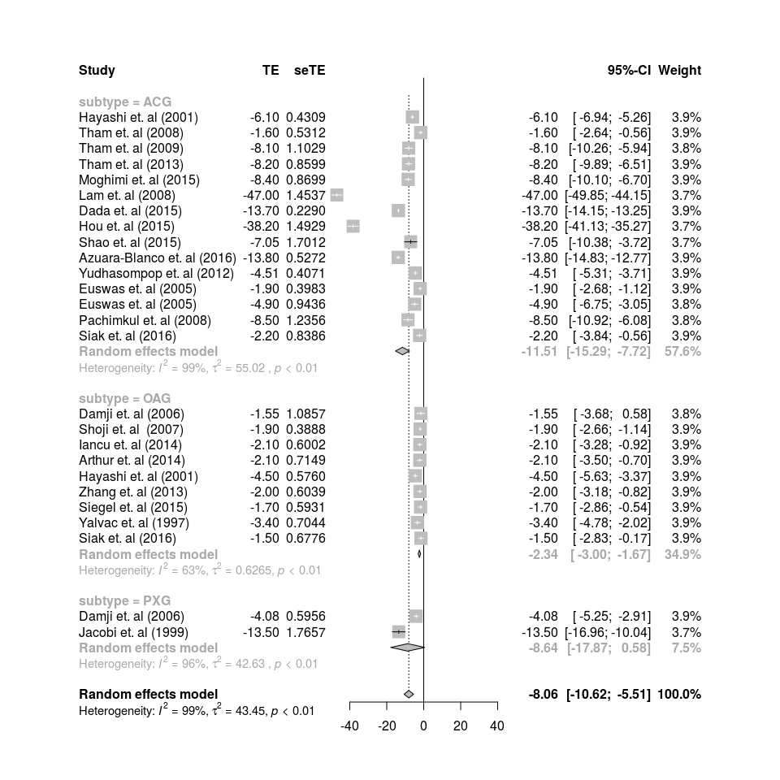

```r
m <- metagen(imp.SixMoIOPChangeMean,
             imp.SixMoIOPChangeSEM,
             study.name,
             data=df,
             subset=!is.na(imp.SixMoIOPChangeSEM),
             byvar=subtype)
forest(m, comb.fixed=FALSE)
```

## 12-month follow up

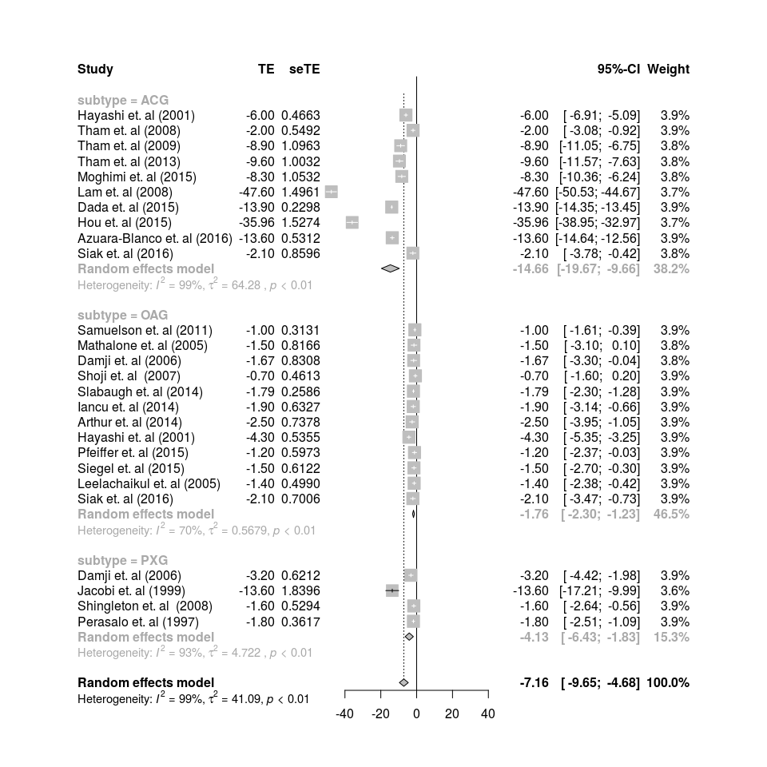

```r
m <- metagen(imp.OneYIOPChangeMean,
             imp.OneYIOPChangeSEM,
             study.name,
             data=df,
             subset=!is.na(imp.OneYIOPChangeSEM),
             byvar=subtype)
forest(m, comb.fixed=FALSE)
```

## Last period

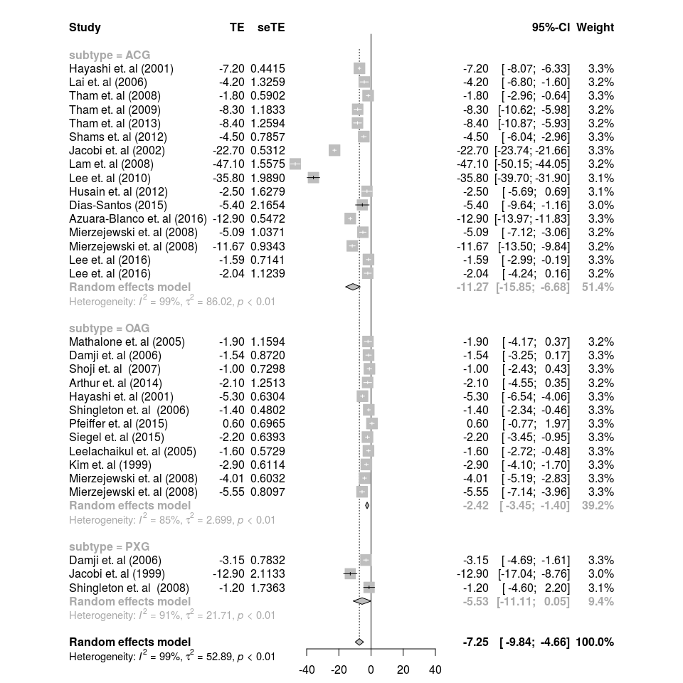

```r
m <- metagen(imp.LastPeriodIOPChangeMean,
             imp.LastPeriodIOPChangeSEM,
             study.name,
             data=df,
             subset=!is.na(imp.LastPeriodIOPChangeSEM) & MIGsYorN == 'N',
             byvar=subtype)
forest(m, comb.fixed=FALSE)
```

## Meds

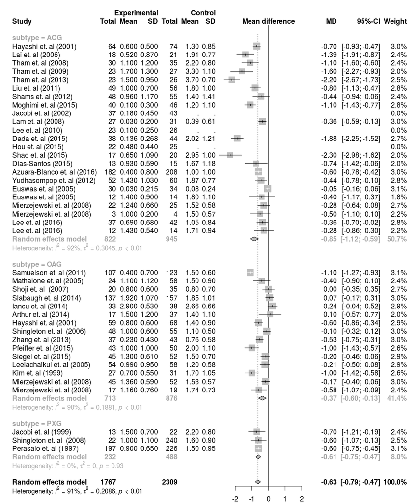

```r
m <- metacont(imp.LastPeriodEyes,
              RxPostOpMean,
              imp.RxPostOpStdDev,
              PreOpEyes,
              RxPreOpMean,
              imp.RxPreOpStdDev,
              study.name,
              data=df,
              subset=!is.na(imp.RxPostOpStdDev) & MIGsYorN == 'N',
              byvar=subtype)
forest(m, comb.fixed=FALSE)
```

# Impute under every scenario

```r
results <- list()
for(loss in c('lo', 'hi')) {
  for(corr in c('lo', 'hi')) {
    for(delta in c('lo', 'hi')) {
      df <- impute.df(df, losses[[loss]], corrs[[corr]], deltas[[delta]])
      s <- (metagen(imp.SixMoIOPChangeMean,
                   imp.SixMoIOPChangeSEM,
                   study.name,
                   data=df,
                   subset=!is.na(imp.SixMoIOPChangeSEM) & MIGsYorN == 'N',
                   byvar=subtype))
      row <- data.frame(loss=loss, corr=corr, delta=delta, m=s$TE.random.w, ci.lo=s$upper.random.w, ci.hi=s$lower.random.w, period=6, subtype=c('ACG', 'OAG', 'PXG'))
      results[[length(results) + 1]] <- row

      s <- (metagen(imp.OneYIOPChangeMean,
                   imp.OneYIOPChangeSEM,
                   study.name,
                   data=df,
                   subset=!is.na(imp.OneYIOPChangeSEM) & MIGsYorN == 'N',
                   byvar=subtype))
      row <- data.frame(loss=loss, corr=corr, delta=delta, m=s$TE.random.w, ci.lo=s$upper.random.w, ci.hi=s$lower.random.w, period=12, subtype=c('ACG', 'OAG', 'PXG'))
      results[[length(results) + 1]] <- row

      s <- (metagen(imp.LastPeriodIOPChangeMean,
                   imp.LastPeriodIOPChangeSEM,
                   study.name,
                   data=df,
                   subset=!is.na(imp.LastPeriodIOPChangeSEM) & MIGsYorN == 'N',
                   byvar=subtype))
      row <- data.frame(loss=loss, corr=corr, delta=delta, m=s$TE.random.w, ci.lo=s$upper.random.w, ci.hi=s$lower.random.w, period=18, subtype=c('ACG', 'OAG', 'PXG'))
      results[[length(results) + 1]] <- row
    }
  }
}

all.df <- do.call(rbind, results)

p <- position_dodge(width=1)
ggplot(all.df, aes(x=period, y = m, ymin=ci.lo, ymax=ci.hi, color=subtype)) + geom_pointrange(position=p)

summary(metagen(imp.LastPeriodIOPChangeMean,
             imp.LastPeriodIOPChangeSEM,
             study.name,
             data=df,
             subset=!is.na(imp.LastPeriodIOPChangeSEM) & MIGsYorN == 'N',
             byvar=subtype))

summary(metagen(imp.LastPeriodIOPChangeMean,
             imp.LastPeriodIOPChangeSEM,
             study.name,
             data=df,
             subset=!is.na(imp.LastPeriodIOPChangeSEM) & MIGsYorN == 'N',
             byvar=subtype))
```

# Sanity check data graphically

Check the relationship between RxPreOpMean and s.d.

```r
ggplot(df, aes(x = RxPreOpMean, y = RxPreOpStdDev)) +
  geom_point() +
  coord_cartesian(y=c(0, 1.5)) +
  stat_function(fun = function(x) sqrt((x - floor(x)) * (1 - (x - floor(x)))), color="gray70")
```

```r
ggplot(df, aes(x = RxPostOpMean, y = RxPostOpStdDev)) + geom_point() +
  stat_function(fun = function(x) sqrt((x - floor(x)) * (1 - (x - floor(x)))), color="gray70")
```

Check that changes add up.

```r
ggplot(df, aes(x = SixMoIOPMean - PreOpIOPMean, y = SixMoAbsIOPChangeMean, label = study.name)) +
  geom_point() +
  coord_cartesian(xlim=c(-10, 0)) +
  geom_abline() +
  geom_text_repel()
```

```r
ggplot(df, aes(x = OneYIOPMean - PreOpIOPMean, y = OneYAbsIOPChangeMean, label = study.name)) +
  geom_point() +
  coord_cartesian(xlim=c(-10, 0)) +
  geom_abline() +
  geom_text_repel()
```

```r
ggplot(df, aes(x = LastPeriodIOPMean - PreOpIOPMean, y = LastPeriodAbsIOPChangeMean, label = study.name)) +
  geom_point() +
  coord_cartesian(xlim=c(-25, 0)) +
  geom_abline() +
  geom_text_repel()
```

Examine loss at one year.

```r
ggplot(df, aes(x=PreOpEyes, y=OneYEyes, label=study.name)) +
  geom_point(color="red") +
  geom_abline() +
  geom_text_repel() + coord_cartesian(xlim=c(0, 250), ylim=c(0, 250))
```

```r
ggplot(df, aes(x=OneYEyes / PreOpEyes, label=study.name)) +
  geom_histogram() +
  coord_cartesian()
```

```r
ggplot(df, aes(x=subtype, fill=MIGsYorN)) + geom_histogram(stat="count", position = 'dodge')
```

Look at the distribution of eyes and IOP means.

```r
ggplot(df, aes(x=PreOpEyes, y=PreOpIOPMean)) + geom_point()
```

Look at number of eyes and standard deviation.

```r
ggplot(df, aes(x=PreOpEyes, y=PreOpIOPStdDev, label=study.name)) + geom_point(color="red") + geom_text_repel(nudge_x = 5)
```

```r
ggplot(df, aes(x=PreOpEyes, y=SixMoAbsIOPChangeStdDev, label=study.name)) + geom_point(color="red") + geom_text_repel(nudge_x = 5)
```

```r
ggplot(df, aes(x=PreOpEyes, y=SixMoIOPStdDev, label=study.name)) + geom_point(color="red") + geom_text_repel(nudge_x = 5)
```

```r
ggplot(df, aes(x=PreOpEyes, y=OneYAbsIOPChangeStdDev, label=study.name)) + geom_point(color="red") + geom_text_repel(nudge_x = 5)
```

```r
ggplot(df, aes(x=PreOpEyes, y=OneYIOPStdDev, label=study.name)) + geom_point(color="red") + geom_text_repel(nudge_x = 5)
```

```r
ggplot(df, aes(x=PreOpEyes, y=LastPeriodAbsIOPChangeStdDev, label=study.name)) + geom_point(color="red") + geom_text_repel(nudge_x = 5)
```

```r
ggplot(df, aes(x=PreOpEyes, y=SixMoIOPStdDev, label=study.name)) + geom_point(color="red") + geom_text_repel(nudge_x = 5)
```

# Some notes on the analysis and the studies

- None of the studies are randomized, except the EAGLE one – (2016) Azuara-Bianco et al., Lancet
- There’s no control arm in any of the studies
- Main outcome is IOP drop
  - The older studies are phaco + glaucoma surgery
  - The new ones are phaco + MIGS - minimally invasive glaucoma surgery

## Slicings to look at

- MIGS
  - Don’t look at MIGS
- Type of glaucoma:
  - OAG -> open angle glaucoma ** ~2-3mm **
  - NTG -> normal tension glaucoma ?
  - ACG -> angle closure glaucoma ** known to be effective **
  - PXG: pseudo-exfoliation ?

## Dimensions to look at - meta-regression

- Initial severity (IOP before)
- Size of study (number of eyes)
- Year

## Different outcomes

- Primary is IOP drop
  - time points 6 mo, 12 mo, (last time point)
  - most important is 12 months
- Number of meds
  - Huge confound, because it’s controlled by the doctor
  - Meds themselves decrease the IOP
  - A handful of studies use washout pre and post (measuring the IOP without meds) to undo the confounding
    - EAGLE, Samuelson studies have washout
    - Lack of washout will have a tendency to decrease the apparent effectiveness of the studies
  - One med ~= 20% decrease in IOP
  - One med := decrease in quality of life
  - RxPostOpMean is at the same time as LastPeriod
- (visual acuity but it’s kind of obvious)

## Additional analyses to perform

- Funnel plot for small / medium large studies
- Deal appropriately with multiple arms of same study, e.g. Damji et al., Merz…
- Deal with three forms of lossiness:
  - Absolutes reported, relatives needed
  - Can patch up using estimate of rho – sqrt(s_1 ** 2 + s_2 ** 2 - 2 * rho * s_1 * s_2)
  - Try rho = 0, rho = 0.5
  - Loss of follow-up
  - Can deal with by assuming that follow up is either MCAR or worse than MCAR
  - Try mean_delta = 0, mean_delta = -3, mean_delta = -5
  - Not all metrics reported for every study
  - Use mvmeta